# Análisis de Componentes Principales (PCA) — Leonard et al. (2020)

2026-06-29

Este script realiza el análisis exploratorio de las tres matrices ómicas mediante PCA.

# Carga de librerías y datos

```r
library(tidyverse)
library(PLSandO)
library(gridExtra)
library(knitr)
library(here)

processed_dir <- here("data", "processed", "leonard_2020")

species_clr_data     <- readRDS(file.path(processed_dir, "species_clr_data.rds"))
pathways_clr_data    <- readRDS(file.path(processed_dir, "pathways_clr_data.rds"))
metabolites_log_data <- readRDS(file.path(processed_dir, "metabolites_log_data.rds"))

dim(species_clr_data)
```

```
## [1]  87 199
```

```r
dim(pathways_clr_data)
```

```
## [1]  87 121
```

```r
dim(metabolites_log_data)
```

```
## [1] 87 69
```

# Separación de metadatos y matrices numéricas

```r
metadata_cols <- c(
  "PaperID", "time_point", "country", "Delivery_Mode", "Gender",
  "Genetic_Risk", "Feeding_Type",
  "Maternal_antibiotics_during_Delivery",
  "Infant_antibiotics_at_Birth",
  "Infant_antibiotics_before_6mo",
  "Antibiotics_Exposure_at_Birth",
  "Exposure_to_Environmental_Factors",
  "Genetic_Risk_Group",
  "Enrollment_Sample", "Three_Month_Sample", "Four_Six_Month_Sample"
)

species_meta <- species_clr_data %>% select(any_of(metadata_cols))
species_X    <- species_clr_data %>%
  select(-any_of(metadata_cols)) %>%
  mutate(across(everything(), as.numeric)) %>%
  as.data.frame()

rownames(species_X) <- paste(species_meta$PaperID, species_meta$time_point, sep = "_")

pathways_meta <- pathways_clr_data %>% select(any_of(metadata_cols))
pathways_X    <- pathways_clr_data %>%
  select(-any_of(metadata_cols)) %>%
  mutate(across(everything(), as.numeric)) %>%
  as.data.frame()

rownames(pathways_X) <- paste(pathways_meta$PaperID, pathways_meta$time_point, sep = "_")

metabolites_meta <- metabolites_log_data %>% select(any_of(metadata_cols))
metabolites_X    <- metabolites_log_data %>%
  select(-any_of(metadata_cols)) %>%
  mutate(across(everything(), as.numeric)) %>%
  as.data.frame()

rownames(metabolites_X) <- paste(metabolites_meta$PaperID, metabolites_meta$time_point, sep = "_")

species_time <- factor(species_meta$time_point, levels = c("Enrollment", "3_months", "4_6_months"))
pathways_time <- factor(pathways_meta$time_point, levels = c("Enrollment", "3_months", "4_6_months"))
metabolites_time <- factor(metabolites_meta$time_point, levels = c("Enrollment", "3_months", "4_6_months"))
```

Función auxiliar reutilizada en la detección de anómalos de las tres ómicas (escalado centrado y estándar): para cada muestra anómala, devuelve las `n` variables que más contribuyen a su anomalía.

```r
get_top_contrib_list <- function(contrib_matrix, n = 10) {
  lapply(rownames(contrib_matrix), function(sample_name) {
    row <- contrib_matrix[sample_name, ]
    top <- row[order(abs(row), decreasing = TRUE)][1:n]
    tibble(
      sample_id    = sample_name,
      pathway      = names(top),
      contribution = as.numeric(top)
    )
  })
}
```

# PCA — Species

## Escalado centrado (`scaling = "center"`)

Se replica el mismo flujo que en el escalado estándar (elegido para el análisis principal), con `scaling = "center"`, para poder comparar ambos y justificar en la memoria la elección final del escalado.

### Cálculo y scree plot

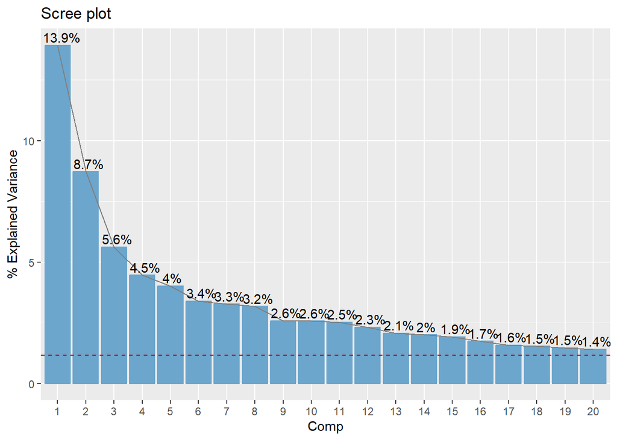

```r
species_pca_ctr <- pca(species_X, ncomp = NULL, algo = "nipals", scaling = "center")
pcaPlot(species_pca_ctr, type = "scree")
```

### Score plots — Exposición ambiental

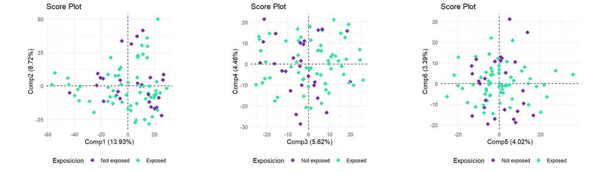

```r
p1 <- pcaPlot(species_pca_ctr, type = "scores", comp = 1:2,
              colBy = data.frame(Exposicion = species_meta$Exposure_to_Environmental_Factors),
              labels = FALSE, ellipses = FALSE)
p2 <- pcaPlot(species_pca_ctr, type = "scores", comp = 3:4,
              colBy = data.frame(Exposicion = species_meta$Exposure_to_Environmental_Factors),
              labels = FALSE, ellipses = FALSE)
p3 <- pcaPlot(species_pca_ctr, type = "scores", comp = 5:6,
              colBy = data.frame(Exposicion = species_meta$Exposure_to_Environmental_Factors),
              labels = FALSE, ellipses = FALSE)
grid.arrange(p1, p2, p3, nrow = 1)
```

### Score plots — Riesgo genético

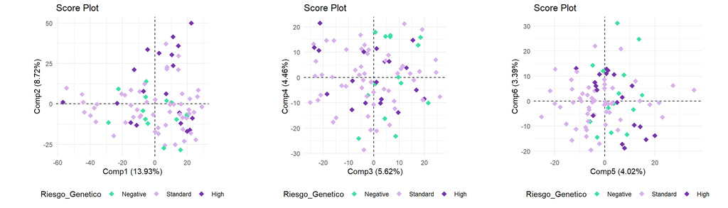

```r
p1 <- pcaPlot(species_pca_ctr, type = "scores", comp = 1:2,
              colBy = data.frame(Riesgo_Genetico = species_meta$Genetic_Risk_Group),
              labels = FALSE, ellipses = FALSE)
p2 <- pcaPlot(species_pca_ctr, type = "scores", comp = 3:4,
              colBy = data.frame(Riesgo_Genetico = species_meta$Genetic_Risk_Group),
              labels = FALSE, ellipses = FALSE)
p3 <- pcaPlot(species_pca_ctr, type = "scores", comp = 5:6,
              colBy = data.frame(Riesgo_Genetico = species_meta$Genetic_Risk_Group),
              labels = FALSE, ellipses = FALSE)
grid.arrange(p1, p2, p3, nrow = 1)
```

### Score plots — Tiempo

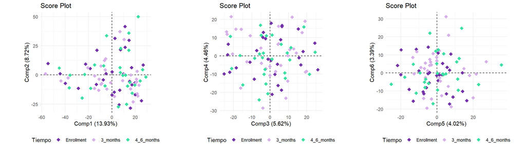

```r
p1 <- pcaPlot(species_pca_ctr, type = "scores", comp = 1:2,
              colBy = data.frame(Tiempo = species_time),
              labels = FALSE, ellipses = FALSE)
p2 <- pcaPlot(species_pca_ctr, type = "scores", comp = 3:4,
              colBy = data.frame(Tiempo = species_time),
              labels = FALSE, ellipses = FALSE)
p3 <- pcaPlot(species_pca_ctr, type = "scores", comp = 5:6,
              colBy = data.frame(Tiempo = species_time),
              labels = FALSE, ellipses = FALSE)
grid.arrange(p1, p2, p3, nrow = 1)
```

### Score plots — País

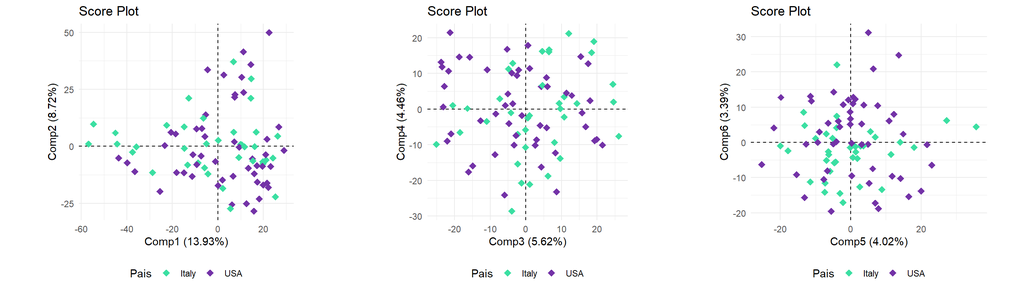

```r
p1 <- pcaPlot(species_pca_ctr, type = "scores", comp = 1:2,
              colBy = data.frame(Pais = species_meta$country),
              labels = FALSE, ellipses = FALSE)
p2 <- pcaPlot(species_pca_ctr, type = "scores", comp = 3:4,
              colBy = data.frame(Pais = species_meta$country),
              labels = FALSE, ellipses = FALSE)
p3 <- pcaPlot(species_pca_ctr, type = "scores", comp = 5:6,
              colBy = data.frame(Pais = species_meta$country),
              labels = FALSE, ellipses = FALSE)
grid.arrange(p1, p2, p3, nrow = 1)
```

### Score plots — Modo de parto

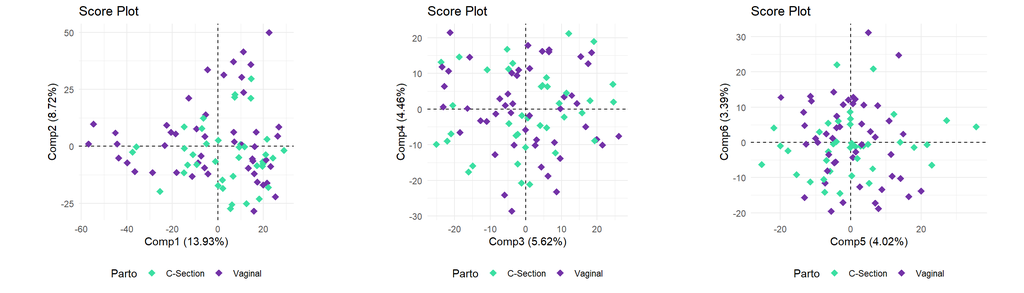

```r
p1 <- pcaPlot(species_pca_ctr, type = "scores", comp = 1:2,
              colBy = data.frame(Parto = species_meta$Delivery_Mode),
              labels = FALSE, ellipses = FALSE)
p2 <- pcaPlot(species_pca_ctr, type = "scores", comp = 3:4,
              colBy = data.frame(Parto = species_meta$Delivery_Mode),
              labels = FALSE, ellipses = FALSE)
p3 <- pcaPlot(species_pca_ctr, type = "scores", comp = 5:6,
              colBy = data.frame(Parto = species_meta$Delivery_Mode),
              labels = FALSE, ellipses = FALSE)
grid.arrange(p1, p2, p3, nrow = 1)
```

### Score plots — Tipo de alimentación

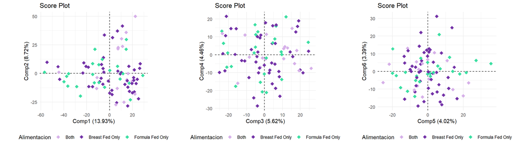

```r
p1 <- pcaPlot(species_pca_ctr, type = "scores", comp = 1:2,
              colBy = data.frame(Alimentacion = species_meta$Feeding_Type),
              labels = FALSE, ellipses = FALSE)
p2 <- pcaPlot(species_pca_ctr, type = "scores", comp = 3:4,
              colBy = data.frame(Alimentacion = species_meta$Feeding_Type),
              labels = FALSE, ellipses = FALSE)
p3 <- pcaPlot(species_pca_ctr, type = "scores", comp = 5:6,
              colBy = data.frame(Alimentacion = species_meta$Feeding_Type),
              labels = FALSE, ellipses = FALSE)
grid.arrange(p1, p2, p3, nrow = 1)
```

### Score plots — Sexo

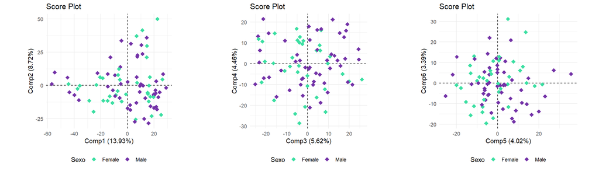

```r
p1 <- pcaPlot(species_pca_ctr, type = "scores", comp = 1:2,
              colBy = data.frame(Sexo = species_meta$Gender),
              labels = FALSE, ellipses = FALSE)
p2 <- pcaPlot(species_pca_ctr, type = "scores", comp = 3:4,
              colBy = data.frame(Sexo = species_meta$Gender),
              labels = FALSE, ellipses = FALSE)
p3 <- pcaPlot(species_pca_ctr, type = "scores", comp = 5:6,
              colBy = data.frame(Sexo = species_meta$Gender),
              labels = FALSE, ellipses = FALSE)
grid.arrange(p1, p2, p3, nrow = 1)
```

### Loadings — Correlation plots

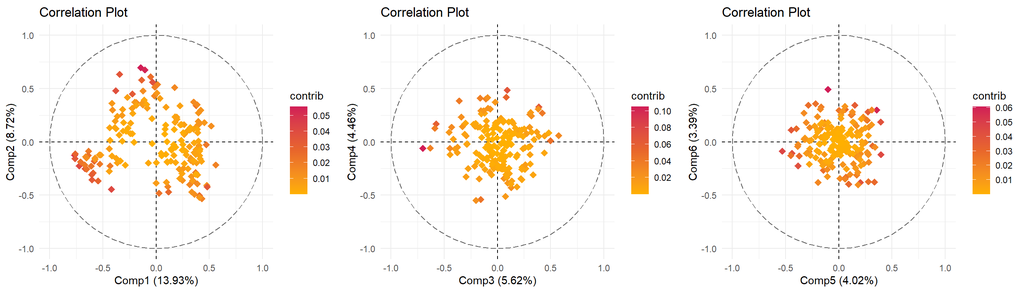

```r
l1 <- pcaPlot(species_pca_ctr, type = "corr", comp = 1:2,
              colBy = "contrib", shape = "point", labels = FALSE, repel = TRUE, col = "hot")
l2 <- pcaPlot(species_pca_ctr, type = "corr", comp = 3:4,
              colBy = "contrib", shape = "point", labels = FALSE, repel = TRUE, col = "hot")
l3 <- pcaPlot(species_pca_ctr, type = "corr", comp = 5:6,
              colBy = "contrib", shape = "point", labels = FALSE, repel = TRUE, col = "hot")
grid.arrange(l1, l2, l3, ncol = 3)
```

### Loadings — Top 10 especies

**PC1 y PC2**

```r
tibble(
  variable    = rownames(species_pca_ctr$loadings),
  loading_PC1 = species_pca_ctr$loadings[, 1],
  loading_PC2 = species_pca_ctr$loadings[, 2]
) %>%
  mutate(contribution_PC12 = loading_PC1^2 + loading_PC2^2) %>%
  arrange(desc(contribution_PC12)) %>%
  slice_head(n = 10) %>%
  kable(caption = "Centrado — Top 10 especies PC1/PC2")
```

Centrado — Top 10 especies PC1/PC2

| variable | loading_PC1 | loading_PC2 | contribution_PC12 |
| --- | --- | --- | --- |
| Flavonifractor_plautii | -0.0382386 | 0.2329957 | 0.0557492 |
| Clostridium_orbiscindens | -0.0284575 | 0.2303503 | 0.0538711 |
| Bacteroides_dorei | -0.2188025 | -0.0455168 | 0.0499463 |
| Bacteroides_fragilis | -0.1210602 | -0.1615495 | 0.0407538 |
| Bacteroides_thetaiotaomicron | -0.1877059 | -0.0739482 | 0.0407018 |
| Ruminococcus_gnavus | -0.1031204 | 0.1648542 | 0.0378107 |
| Clostridium_u_s | -0.0089345 | 0.1929779 | 0.0373203 |
| Bacteroides_uniformis | -0.1725151 | -0.0823413 | 0.0365416 |
| Christensenella_timonensis | -0.0742641 | 0.1728736 | 0.0354005 |
| Bacteroides_vulgatus | -0.1815558 | -0.0470265 | 0.0351740 |

**PC3 y PC4**

```r
tibble(
  variable    = rownames(species_pca_ctr$loadings),
  loading_PC3 = species_pca_ctr$loadings[, 3],
  loading_PC4 = species_pca_ctr$loadings[, 4]
) %>%
  mutate(contribution_PC34 = loading_PC3^2 + loading_PC4^2) %>%
  arrange(desc(contribution_PC34)) %>%
  slice_head(n = 10) %>%
  kable(caption = "Centrado — Top 10 especies PC3/PC4")
```

Centrado — Top 10 especies PC3/PC4

| variable | loading_PC3 | loading_PC4 | contribution_PC34 |
| --- | --- | --- | --- |
| Bifidobacterium_bifidum | -0.3230722 | -0.0304436 | 0.1053025 |
| Lachnospiraceae_bacterium | 0.0431951 | 0.2557708 | 0.0672845 |
| Klebsiella_u_s | 0.1814574 | 0.1719742 | 0.0625019 |
| Bifidobacterium_pseudocatenulatum | -0.2318539 | 0.0754251 | 0.0594452 |
| Klebsiella_oxytoca | 0.0402590 | 0.2285099 | 0.0538376 |
| Staphylococcus_epidermidis | 0.2147935 | 0.0057301 | 0.0461691 |
| Ruminococcus_u_s | -0.0525252 | -0.2013164 | 0.0432872 |
| Klebsiella_variicola | 0.1626162 | 0.1171347 | 0.0401646 |
| Streptococcus_lutetiensis | -0.1251467 | 0.1503955 | 0.0382805 |
| Bifidobacterium_adolescentis | -0.1859474 | 0.0454243 | 0.0366398 |

**PC5 y PC6**

```r
tibble(
  variable    = rownames(species_pca_ctr$loadings),
  loading_PC5 = species_pca_ctr$loadings[, 5],
  loading_PC6 = species_pca_ctr$loadings[, 6]
) %>%
  mutate(contribution_PC56 = loading_PC5^2 + loading_PC6^2) %>%
  arrange(desc(contribution_PC56)) %>%
  slice_head(n = 10) %>%
  kable(caption = "Centrado — Top 10 especies PC5/PC6")
```

Centrado — Top 10 especies PC5/PC6

| variable | loading_PC5 | loading_PC6 | contribution_PC56 |
| --- | --- | --- | --- |
| Clostridium_butyricum | -0.0461100 | 0.2422696 | 0.0608207 |
| Veillonella_atypica | 0.1786786 | 0.1629093 | 0.0584655 |
| Bifidobacterium_dentium | -0.2122132 | -0.0375855 | 0.0464471 |
| Bacteroides_u_s | 0.2008841 | -0.0659462 | 0.0447033 |
| Lactobacillus_gasseri | -0.1721315 | -0.1097763 | 0.0416801 |
| Lactobacillus_rhamnosus | -0.1957019 | -0.0517063 | 0.0409728 |
| Bacteroides_stercoris | 0.1792086 | 0.0920335 | 0.0405859 |
| Streptococcus_peroris | 0.0873889 | -0.1789897 | 0.0396741 |
| Lactobacillus_paracasei | -0.1874716 | 0.0499957 | 0.0376452 |
| Tyzzerella_nexilis | 0.1262961 | 0.1410168 | 0.0358364 |

```r
species_pca_ctr <- pca(
  species_X,
  ncomp   = 6,
  algo    = "nipals",
  scaling = "center"
)
```

### Detección de muestras anómalas (centrado)

```r
par(mfrow = c(1, 2))

species_out_RSS_ctr <- pcaOutliers(species_pca_ctr, ncomp = species_pca_ctr$ncomp, method = "RSS", conf = 0.95)
species_out_T2_ctr  <- pcaOutliers(species_pca_ctr, ncomp = species_pca_ctr$ncomp, method = "T2",  conf = 0.95)
```

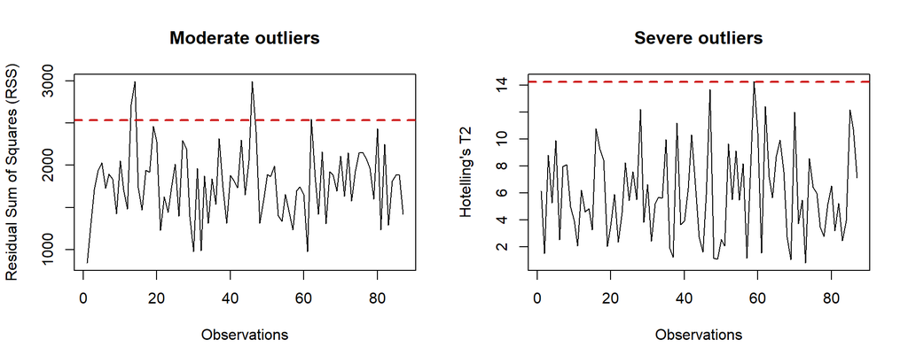

```r
par(mfrow = c(1, 1))
```

```r
species_moderate_ctr <- sort(
  species_out_RSS_ctr$RSS[species_out_RSS_ctr$ModerateOutliers],
  decreasing = TRUE
)

species_severe_ctr <- sort(
  species_out_T2_ctr$T2[species_out_T2_ctr$SevereOutliers],
  decreasing = TRUE
)

cat("Anómalos moderados (RSS) al 95 :\n"); print(species_moderate_ctr)
```

```
## Anómalos moderados (RSS) al 95 :
```

```
## subject_24_Enrollment   subject_28_3_months subject_23_Enrollment
##              2992.961              2992.281              2722.168
##  subject_9_4_6_months
##              2546.955
```

```r
cat("\nAnómalos severos (T²) al 95 :\n");   print(species_severe_ctr)
```

```
##
## Anómalos severos (T²) al 95 :
```

```
## subject_1_3_months
##           14.28471
```

```r
par(mfrow = c(1, 2))

species_out_RSS_99_ctr <- pcaOutliers(species_pca_ctr, ncomp = species_pca_ctr$ncomp, method = "RSS", conf = 0.99)
species_out_T2_99_ctr  <- pcaOutliers(species_pca_ctr, ncomp = species_pca_ctr$ncomp, method = "T2",  conf = 0.99)
```

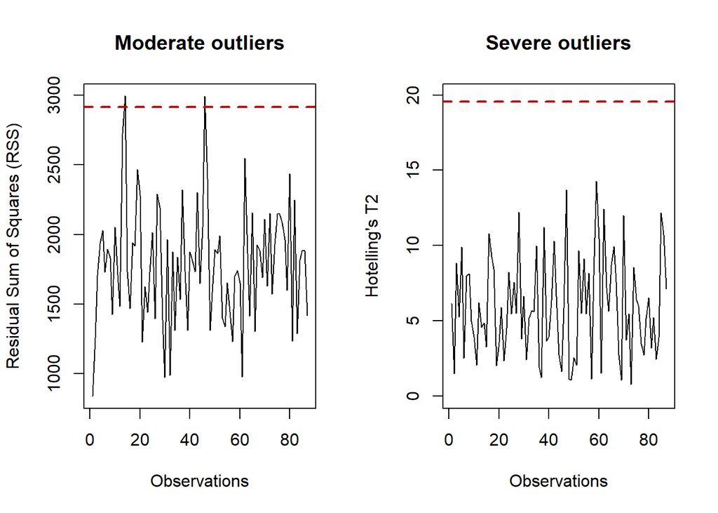

```r
par(mfrow = c(1, 1))
```

```r
species_moderate_99_ctr <- sort(species_out_RSS_99_ctr$RSS[species_out_RSS_99_ctr$ModerateOutliers],
                    decreasing = TRUE)
species_severe_99_ctr   <- sort(species_out_T2_99_ctr$T2[species_out_T2_99_ctr$SevereOutliers],
                    decreasing = TRUE)

cat("Moderados (RSS) al 99 :\n"); print(species_moderate_99_ctr)
```

```
## Moderados (RSS) al 99 :
```

```
## subject_24_Enrollment   subject_28_3_months
##              2992.961              2992.281
```

```r
cat("Severos   (T²) al 99 :\n");  print(species_severe_99_ctr)
```

```
## Severos   (T²) al 99 :
```

```
## named numeric(0)
```

```r
species_mod_contrib_99_ctr <- outlierContrib(species_pca_ctr, species_out_RSS_99_ctr)
```

```
## There are no severe outliers in the data or they were not computed.
```

```
## There are 2 moderate outliers in the data provided.
```

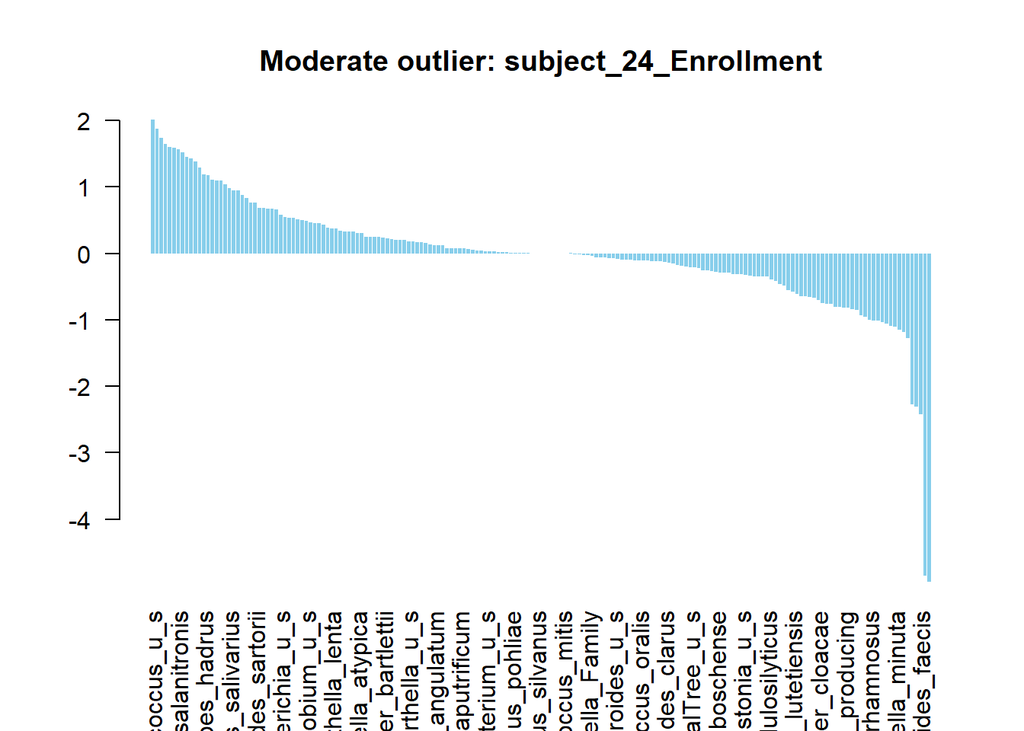

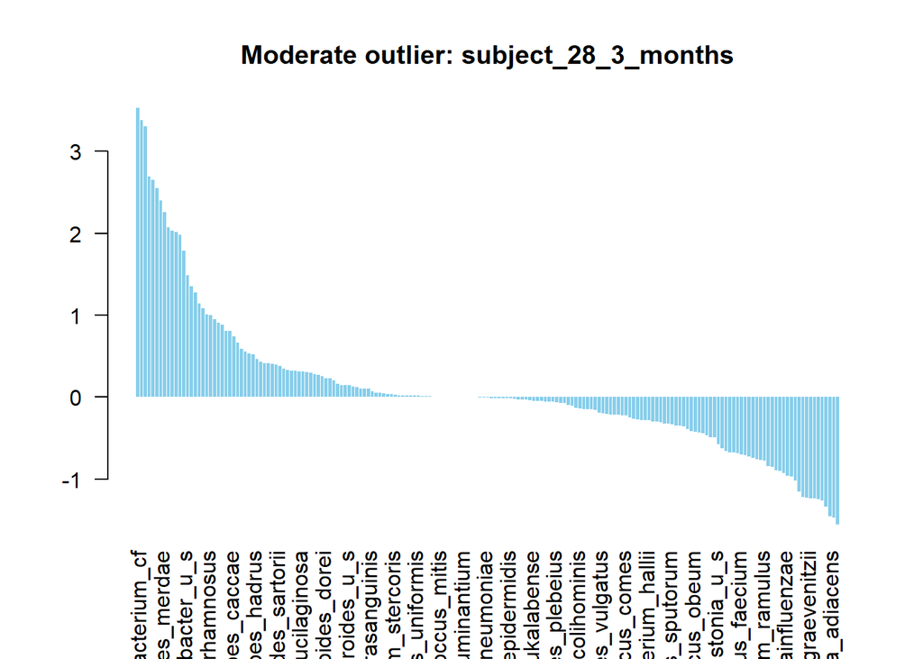

```r
species_sev_contrib_99_ctr <- outlierContrib(species_pca_ctr, species_out_T2_99_ctr)
```

```
## There are no severe outliers in the data or they were not computed.
```

```
## There are no moderate outliers in the data or they were not computed.
```

```r
top10_moderate_ctr <- get_top_contrib_list(species_mod_contrib_99_ctr$contribRSS)
top10_moderate_ctr
```

```
## [[1]]
## # A tibble: 10 × 3
##    sample_id             pathway                        contribution
##    <chr>                 <chr>                                 <dbl>
##  1 subject_24_Enrollment Lachnospiraceae_bacterium             -4.94
##  2 subject_24_Enrollment Bifidobacterium_kashiwanohense        -4.86
##  3 subject_24_Enrollment Bacteroides_faecis                    -2.42
##  4 subject_24_Enrollment Bifidobacterium_catenulatum           -2.31
##  5 subject_24_Enrollment Bacteroides_thetaiotaomicron          -2.27
##  6 subject_24_Enrollment Enterococcus_u_s                       2.01
##  7 subject_24_Enrollment Klebsiella_u_s                         1.88
##  8 subject_24_Enrollment Klebsiella_oxytoca                     1.74
##  9 subject_24_Enrollment Collinsella_u_s                        1.64
## 10 subject_24_Enrollment Subdoligranulum_u_s                    1.59
##
## [[2]]
## # A tibble: 10 × 3
##    sample_id           pathway                      contribution
##    <chr>               <chr>                               <dbl>
##  1 subject_28_3_months Faecalibacterium_cf                  3.53
##  2 subject_28_3_months Streptococcus_pasteurianus           3.38
##  3 subject_28_3_months Faecalibacterium_prausnitzii         3.30
##  4 subject_28_3_months Streptococcus_vestibularis           2.69
##  5 subject_28_3_months Roseburia_hominis                    2.65
##  6 subject_28_3_months Streptococcus_macedonicus            2.55
##  7 subject_28_3_months Parabacteroides_merdae               2.40
##  8 subject_28_3_months Christensenella_minuta               2.26
##  9 subject_28_3_months Lactococcus_lactis                   2.07
## 10 subject_28_3_months Clostridium_perfringens              2.03
```

```r
top10_severe_ctr <- get_top_contrib_list(species_sev_contrib_99_ctr$contribT2)
top10_severe_ctr
```

```
## list()
```

## Escalado estándar (`scaling = "standard"`)

### Cálculo y scree plot

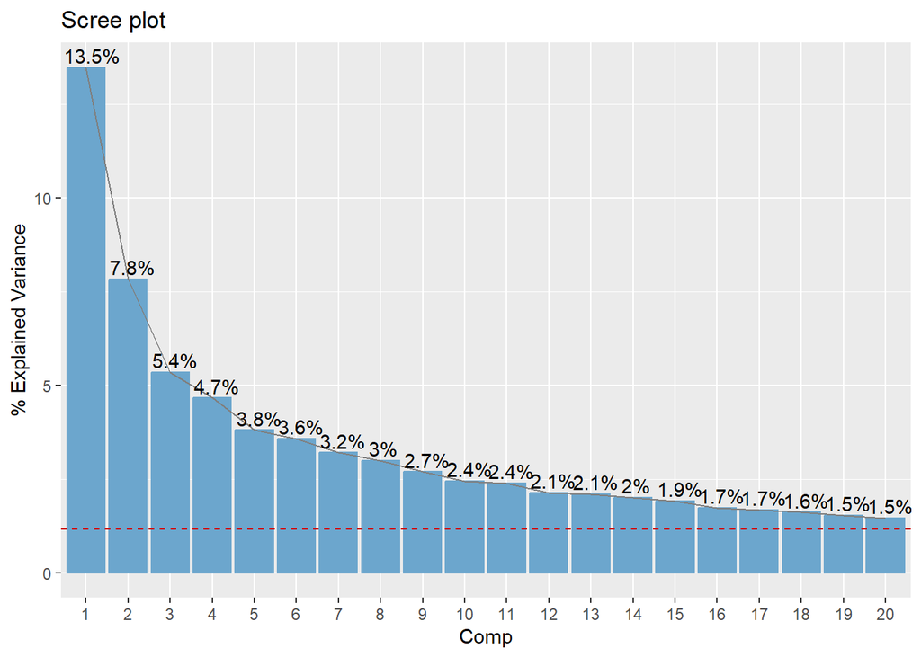

```r
species_pca_std <- pca(species_X, ncomp = NULL, algo = "nipals", scaling = "standard")
pcaPlot(species_pca_std, type = "scree")
```

### Score plots — Exposición ambiental

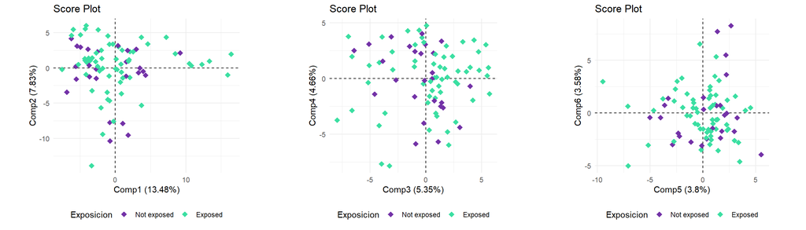

```r
p1 <- pcaPlot(species_pca_std, type = "scores", comp = 1:2,
              colBy = data.frame(Exposicion = species_meta$Exposure_to_Environmental_Factors),
              labels = FALSE, ellipses = FALSE)
p2 <- pcaPlot(species_pca_std, type = "scores", comp = 3:4,
              colBy = data.frame(Exposicion = species_meta$Exposure_to_Environmental_Factors),
              labels = FALSE, ellipses = FALSE)
p3 <- pcaPlot(species_pca_std, type = "scores", comp = 5:6,
              colBy = data.frame(Exposicion = species_meta$Exposure_to_Environmental_Factors),
              labels = FALSE, ellipses = FALSE)
grid.arrange(p1, p2, p3, nrow = 1)
```

### Score plots — Riesgo genético

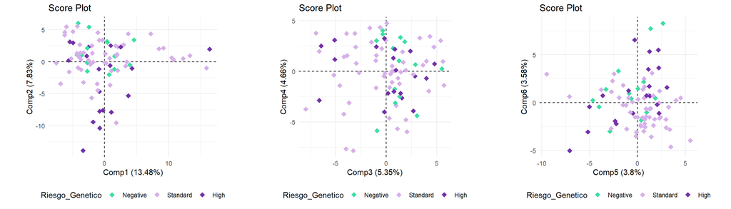

```r
p1 <- pcaPlot(species_pca_std, type = "scores", comp = 1:2,
              colBy = data.frame(Riesgo_Genetico = species_meta$Genetic_Risk_Group),
              labels = FALSE, ellipses = FALSE)
p2 <- pcaPlot(species_pca_std, type = "scores", comp = 3:4,
              colBy = data.frame(Riesgo_Genetico = species_meta$Genetic_Risk_Group),
              labels = FALSE, ellipses = FALSE)
p3 <- pcaPlot(species_pca_std, type = "scores", comp = 5:6,
              colBy = data.frame(Riesgo_Genetico = species_meta$Genetic_Risk_Group),
              labels = FALSE, ellipses = FALSE)
grid.arrange(p1, p2, p3, nrow = 1)
```

### Score plots — Tiempo

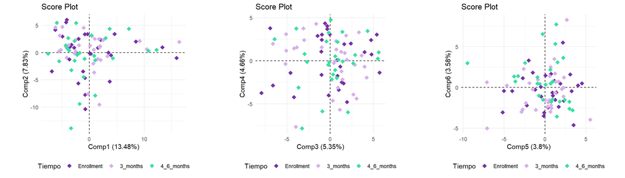

```r
p1 <- pcaPlot(species_pca_std, type = "scores", comp = 1:2,
              colBy = data.frame(Tiempo = species_time),
              labels = FALSE, ellipses = FALSE)
p2 <- pcaPlot(species_pca_std, type = "scores", comp = 3:4,
              colBy = data.frame(Tiempo = species_time),
              labels = FALSE, ellipses = FALSE)
p3 <- pcaPlot(species_pca_std, type = "scores", comp = 5:6,
              colBy = data.frame(Tiempo = species_time),
              labels = FALSE, ellipses = FALSE)
grid.arrange(p1, p2, p3, nrow = 1)
```

### Score plots — País

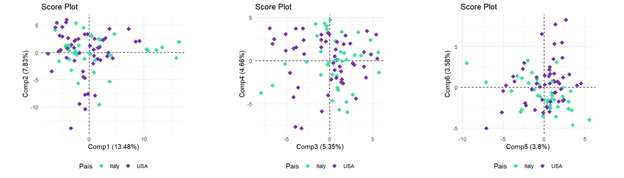

```r
p1 <- pcaPlot(species_pca_std, type = "scores", comp = 1:2,
              colBy = data.frame(Pais = species_meta$country),
              labels = FALSE, ellipses = FALSE)
p2 <- pcaPlot(species_pca_std, type = "scores", comp = 3:4,
              colBy = data.frame(Pais = species_meta$country),
              labels = FALSE, ellipses = FALSE)
p3 <- pcaPlot(species_pca_std, type = "scores", comp = 5:6,
              colBy = data.frame(Pais = species_meta$country),
              labels = FALSE, ellipses = FALSE)
grid.arrange(p1, p2, p3, nrow = 1)
```

### Score plots — Modo de parto

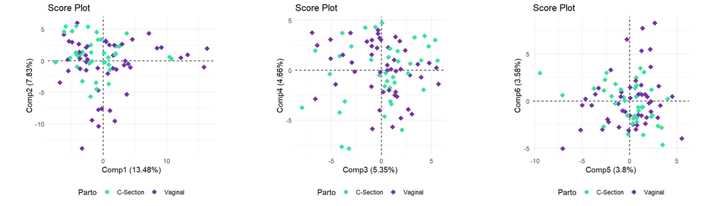

```r
p1 <- pcaPlot(species_pca_std, type = "scores", comp = 1:2,
              colBy = data.frame(Parto = species_meta$Delivery_Mode),
              labels = FALSE, ellipses = FALSE)
p2 <- pcaPlot(species_pca_std, type = "scores", comp = 3:4,
              colBy = data.frame(Parto = species_meta$Delivery_Mode),
              labels = FALSE, ellipses = FALSE)
p3 <- pcaPlot(species_pca_std, type = "scores", comp = 5:6,
              colBy = data.frame(Parto = species_meta$Delivery_Mode),
              labels = FALSE, ellipses = FALSE)
grid.arrange(p1, p2, p3, nrow = 1)
```

### Score plots — Tipo de alimentación

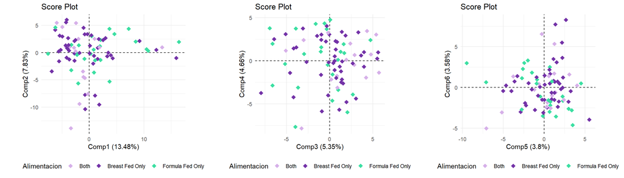

```r
p1 <- pcaPlot(species_pca_std, type = "scores", comp = 1:2,
              colBy = data.frame(Alimentacion = species_meta$Feeding_Type),
              labels = FALSE, ellipses = FALSE)
p2 <- pcaPlot(species_pca_std, type = "scores", comp = 3:4,
              colBy = data.frame(Alimentacion = species_meta$Feeding_Type),
              labels = FALSE, ellipses = FALSE)
p3 <- pcaPlot(species_pca_std, type = "scores", comp = 5:6,
              colBy = data.frame(Alimentacion = species_meta$Feeding_Type),
              labels = FALSE, ellipses = FALSE)
grid.arrange(p1, p2, p3, nrow = 1)
```

### Score plots — Sexo

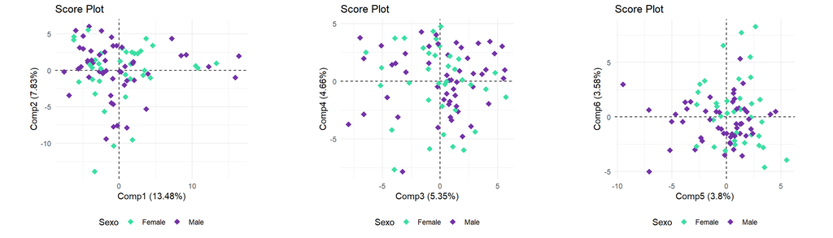

```r
p1 <- pcaPlot(species_pca_std, type = "scores", comp = 1:2,
              colBy = data.frame(Sexo = species_meta$Gender),
              labels = FALSE, ellipses = FALSE)
p2 <- pcaPlot(species_pca_std, type = "scores", comp = 3:4,
              colBy = data.frame(Sexo = species_meta$Gender),
              labels = FALSE, ellipses = FALSE)
p3 <- pcaPlot(species_pca_std, type = "scores", comp = 5:6,
              colBy = data.frame(Sexo = species_meta$Gender),
              labels = FALSE, ellipses = FALSE)
grid.arrange(p1, p2, p3, nrow = 1)
```

### Loadings — Correlation plots

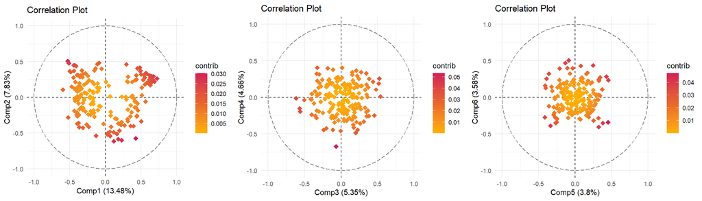

```r
l1 <- pcaPlot(species_pca_std, type = "corr", comp = 1:2,
              colBy = "contrib", shape = "point", labels = FALSE, repel = TRUE, col = "hot")
l2 <- pcaPlot(species_pca_std, type = "corr", comp = 3:4,
              colBy = "contrib", shape = "point", labels = FALSE, repel = TRUE, col = "hot")
l3 <- pcaPlot(species_pca_std, type = "corr", comp = 5:6,
              colBy = "contrib", shape = "point", labels = FALSE, repel = TRUE, col = "hot")
grid.arrange(l1, l2, l3, ncol = 3)
```

### Loadings — Top 10 especies

**PC1 y PC2**

```r
tibble(
  variable    = rownames(species_pca_std$loadings),
  loading_PC1 = species_pca_std$loadings[, 1],
  loading_PC2 = species_pca_std$loadings[, 2]
) %>%
  mutate(contribution_PC12 = loading_PC1^2 + loading_PC2^2) %>%
  arrange(desc(contribution_PC12)) %>%
  slice_head(n = 10) %>%
  kable(caption = "Estándar — Top 10 especies PC1/PC2")
```

Estándar — Top 10 especies PC1/PC2

| variable | loading_PC1 | loading_PC2 | contribution_PC12 |
| --- | --- | --- | --- |
| Christensenella_timonensis | 0.0859084 | -0.1516863 | 0.0303890 |
| Haemophilus_u_s | -0.1059948 | 0.1337580 | 0.0291261 |
| Flavonifractor_plautii | 0.0459601 | -0.1581658 | 0.0271288 |
| Coprobacillus_u_s | 0.0239719 | -0.1627729 | 0.0270697 |
| Haemophilus_influenzae | -0.1028671 | 0.1256496 | 0.0263694 |
| Bacteroides_cellulosilyticus | 0.1457941 | 0.0696475 | 0.0261067 |
| Clostridium_orbiscindens | 0.0363594 | -0.1547924 | 0.0252827 |
| Parabacteroides_merdae | 0.1360195 | 0.0776799 | 0.0245355 |
| Bacteroides_thetaiotaomicron | 0.1307396 | 0.0785224 | 0.0232586 |
| Bacteroides_sartorii | 0.1390682 | 0.0580467 | 0.0227094 |

**PC3 y PC4**

```r
tibble(
  variable    = rownames(species_pca_std$loadings),
  loading_PC3 = species_pca_std$loadings[, 3],
  loading_PC4 = species_pca_std$loadings[, 4]
) %>%
  mutate(contribution_PC34 = loading_PC3^2 + loading_PC4^2) %>%
  arrange(desc(contribution_PC34)) %>%
  slice_head(n = 10) %>%
  kable(caption = "Estándar — Top 10 especies PC3/PC4")
```

Estándar — Top 10 especies PC3/PC4

| variable | loading_PC3 | loading_PC4 | contribution_PC34 |
| --- | --- | --- | --- |
| Gemella_sanguinis | -0.0217002 | -0.2301123 | 0.0534225 |
| Bifidobacterium_adolescentis | -0.1965444 | -0.0051828 | 0.0386566 |
| Bifidobacterium_angulatum | -0.1790758 | -0.0673201 | 0.0366001 |
| Burkholderiales_Order | 0.1676808 | 0.0874093 | 0.0357572 |
| Bifidobacterium_bifidum | -0.1810076 | -0.0522894 | 0.0354979 |
| Ruminococcus_bicirculans | 0.0640077 | -0.1662948 | 0.0317509 |
| Meiothermus_silvanus | 0.1655183 | 0.0642281 | 0.0315215 |
| Streptococcus_lutetiensis | -0.1042591 | 0.1388839 | 0.0301587 |
| Enterococcus_faec | 0.1730690 | 0.0035668 | 0.0299656 |
| Granulicatella_adiacens | -0.0757730 | -0.1524100 | 0.0289704 |

**PC5 y PC6**

```r
tibble(
  variable    = rownames(species_pca_std$loadings),
  loading_PC5 = species_pca_std$loadings[, 5],
  loading_PC6 = species_pca_std$loadings[, 6]
) %>%
  mutate(contribution_PC56 = loading_PC5^2 + loading_PC6^2) %>%
  arrange(desc(contribution_PC56)) %>%
  slice_head(n = 10) %>%
  kable(caption = "Estándar — Top 10 especies PC5/PC6")
```

Estándar — Top 10 especies PC5/PC6

| variable | loading_PC5 | loading_PC6 | contribution_PC56 |
| --- | --- | --- | --- |
| Bifidobacterium_dentium | 0.1722168 | -0.1331764 | 0.0473946 |
| Blautia_u_s | 0.1229326 | -0.1590469 | 0.0404084 |
| Erysipelotrichaceae_bacterium | -0.0327364 | 0.1976351 | 0.0401313 |
| Lactobacillus_rhamnosus | 0.1448051 | -0.1379754 | 0.0400057 |
| Streptococcus_peroris | -0.1272286 | -0.1529233 | 0.0395727 |
| Collinsella_u_s | 0.1628806 | 0.1108142 | 0.0388099 |
| Collinsella_aerofaciens | 0.1732118 | 0.0911433 | 0.0383094 |
| Eubacterium_hallii | 0.0941809 | 0.1702998 | 0.0378721 |
| Streptococcus_pseudopneumoniae | -0.1570167 | -0.1070806 | 0.0361205 |
| Actinomyces_graevenitzii | -0.0504498 | 0.1828898 | 0.0359939 |

```r
species_pca_std <- pca(
  species_X,
  ncomp   = 6,
  algo    = "nipals",
  scaling = "standard"
)
```

## 4.4 Detección de muestras anómalas

Se detectan muestras anómalas mediante dos criterios complementarios. El RSS y el T² de Hotelling. Las muestras detectadas se identifican pero **no se eliminan**.

```r
par(mfrow = c(1, 2))

species_out_RSS <- pcaOutliers(species_pca_std, ncomp = species_pca_std$ncomp,method = "RSS", conf = 0.95)
species_out_T2  <- pcaOutliers(species_pca_std, ncomp = species_pca_std$ncomp,method = "T2",  conf = 0.95)
```

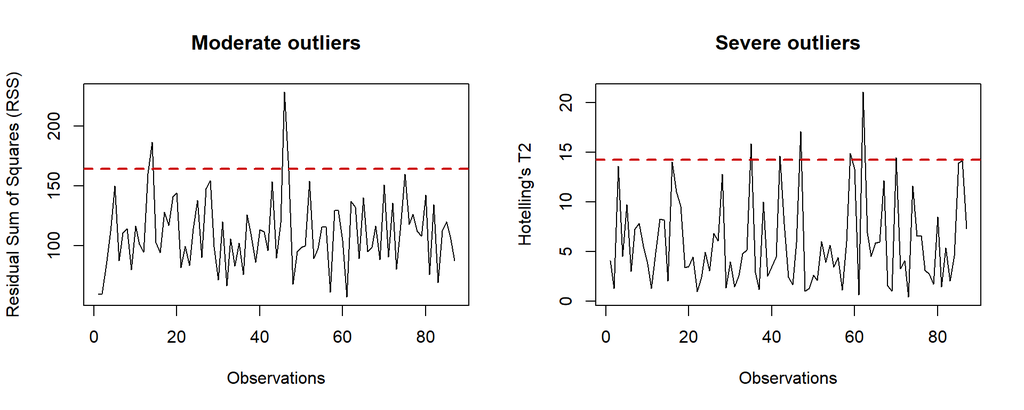

```r
par(mfrow = c(1, 1))
```

```r
species_moderate <- sort(
  species_out_RSS$RSS[species_out_RSS$ModerateOutliers],
  decreasing = TRUE
)

species_severe <- sort(
  species_out_T2$T2[species_out_T2$SevereOutliers],
  decreasing = TRUE
)

cat("Anómalos moderados (RSS) al 95 :\n"); print(species_moderate)
```

```
## Anómalos moderados (RSS) al 95 :
```

```
##   subject_28_3_months subject_24_Enrollment
##              228.6796              186.6659
```

```r
cat("\nAnómalos severos (T²) al 95 :\n");   print(species_severe)
```

```
##
## Anómalos severos (T²) al 95 :
```

```
##  subject_9_4_6_months   subject_29_3_months   subject_14_3_months
##              21.04680              17.09117              15.87431
##    subject_1_3_months   subject_24_3_months subject_20_4_6_months
##              14.89506              14.64481              14.48431
```

```r
par(mfrow = c(1, 2))

species_out_RSS_99 <- pcaOutliers(species_pca_std, ncomp = species_pca_std$ncomp,method = "RSS", conf = 0.99)
species_out_T2_99  <- pcaOutliers(species_pca_std, ncomp = species_pca_std$ncomp,method = "T2",  conf = 0.99)
```

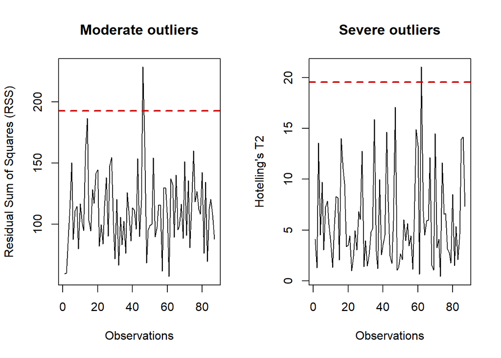

```r
par(mfrow = c(1, 1))
```

```r
moderate_99 <- sort(species_out_RSS_99$RSS[species_out_RSS_99$ModerateOutliers],
                    decreasing = TRUE)
severe_99   <- sort(species_out_T2_99$T2[species_out_T2_99$SevereOutliers],
                    decreasing = TRUE)

cat("Moderados (RSS) al 99 :\n"); print(moderate_99)
```

```
## Moderados (RSS) al 99 :
```

```
## subject_28_3_months
##            228.6796
```

```r
cat("Severos   (T²) al 99 :\n");  print(severe_99)
```

```
## Severos   (T²) al 99 :
```

```
## subject_9_4_6_months
##              21.0468
```

```r
species_mod_contrib_99 <- outlierContrib(species_pca_std, species_out_RSS_99)
```

```
## There are no severe outliers in the data or they were not computed.
```

```
## There are 1 moderate outliers in the data provided.
```

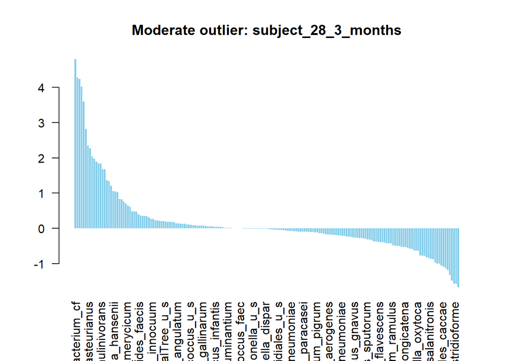

```r
species_sev_contrib_99 <- outlierContrib(species_pca_std, species_out_T2_99)
```

```
## There are 1 severe outliers in the data provided.
```

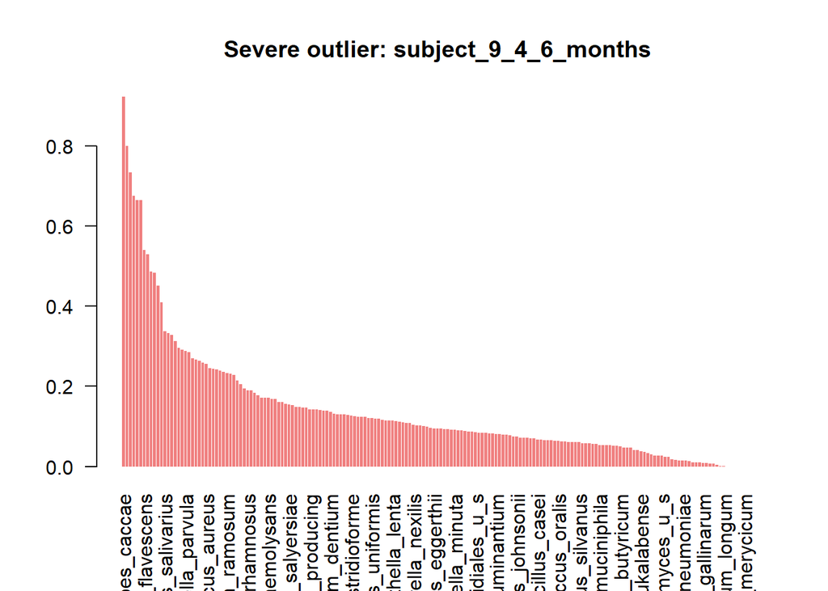

```
## There are no moderate outliers in the data or they were not computed.
```

```r
top10_moderate <- get_top_contrib_list(species_mod_contrib_99$contribRSS)


top10_moderate
```

```
## [[1]]
## # A tibble: 10 × 3
##    sample_id           pathway                      contribution
##    <chr>               <chr>                               <dbl>
##  1 subject_28_3_months Faecalibacterium_cf                  4.80
##  2 subject_28_3_months Roseburia_hominis                    4.28
##  3 subject_28_3_months Roseburia_intestinalis               4.23
##  4 subject_28_3_months Lactococcus_lactis                   4.02
##  5 subject_28_3_months Ruminococcus_bicirculans             3.59
##  6 subject_28_3_months Streptococcus_macedonicus            2.81
##  7 subject_28_3_months Streptococcus_pasteurianus           2.35
##  8 subject_28_3_months Faecalibacterium_prausnitzii         2.28
##  9 subject_28_3_months Anaerostipes_hadrus                  2.03
## 10 subject_28_3_months Anaerostipes_caccae                  1.98
```

```r
top10_severe <-get_top_contrib_list(species_sev_contrib_99$contribT2)

top10_severe
```

```
## [[1]]
## # A tibble: 10 × 3
##    sample_id            pathway                       contribution
##    <chr>                <chr>                                <dbl>
##  1 subject_9_4_6_months Anaerostipes_caccae                  0.923
##  2 subject_9_4_6_months Eubacterium_hallii                   0.800
##  3 subject_9_4_6_months Enterococcus_raffinosus              0.735
##  4 subject_9_4_6_months Eubacterium_ramulus                  0.675
##  5 subject_9_4_6_months Erysipelotrichaceae_bacterium        0.665
##  6 subject_9_4_6_months Clostridium_innocuum                 0.664
##  7 subject_9_4_6_months Enterococcus_flavescens              0.540
##  8 subject_9_4_6_months Enterococcus_casseliflavus           0.530
##  9 subject_9_4_6_months Actinomyces_graevenitzii             0.486
## 10 subject_9_4_6_months Veillonella_u_s                      0.483
```

# PCA — Pathways

## Escalado centrado (`scaling = "center"`)

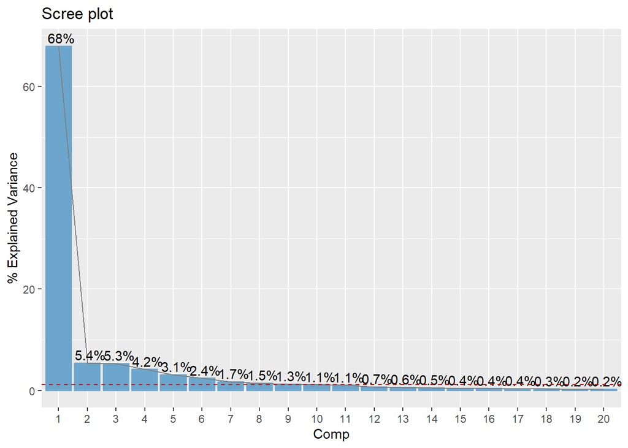

```r
pathways_pca_ctr <- pca(pathways_X, ncomp = NULL, algo = "nipals", scaling = "center")
pcaPlot(pathways_pca_ctr, type = "scree")
```

### Score plots — Exposición ambiental

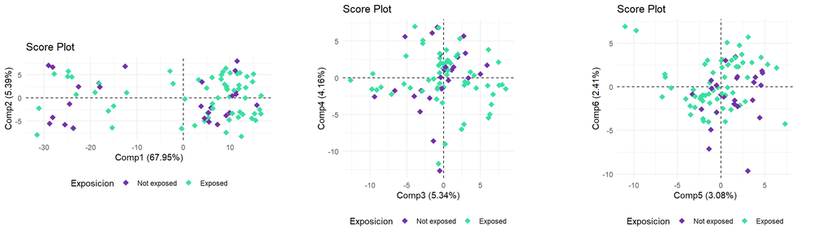

```r
p1 <- pcaPlot(pathways_pca_ctr, type = "scores", comp = 1:2,
              colBy = data.frame(Exposicion = pathways_meta$Exposure_to_Environmental_Factors),
              labels = FALSE, ellipses = FALSE)
p2 <- pcaPlot(pathways_pca_ctr, type = "scores", comp = 3:4,
              colBy = data.frame(Exposicion = pathways_meta$Exposure_to_Environmental_Factors),
              labels = FALSE, ellipses = FALSE)
p3 <- pcaPlot(pathways_pca_ctr, type = "scores", comp = 5:6,
              colBy = data.frame(Exposicion = pathways_meta$Exposure_to_Environmental_Factors),
              labels = FALSE, ellipses = FALSE)
grid.arrange(p1, p2, p3, nrow = 1)
```

### Score plots — Riesgo genético

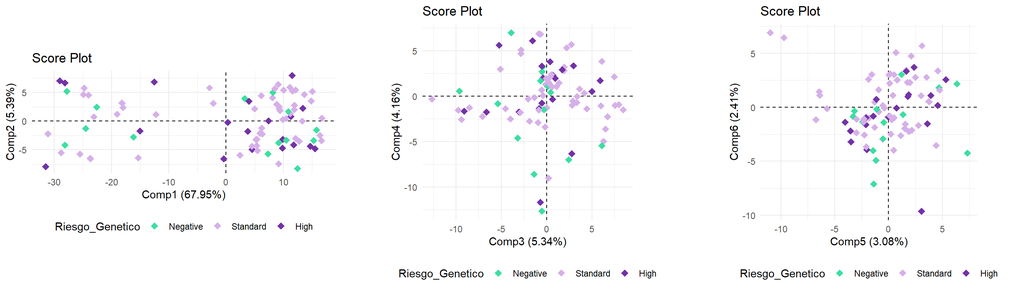

```r
p1 <- pcaPlot(pathways_pca_ctr, type = "scores", comp = 1:2,
              colBy = data.frame(Riesgo_Genetico = pathways_meta$Genetic_Risk_Group),
              labels = FALSE, ellipses = FALSE)
p2 <- pcaPlot(pathways_pca_ctr, type = "scores", comp = 3:4,
              colBy = data.frame(Riesgo_Genetico = pathways_meta$Genetic_Risk_Group),
              labels = FALSE, ellipses = FALSE)
p3 <- pcaPlot(pathways_pca_ctr, type = "scores", comp = 5:6,
              colBy = data.frame(Riesgo_Genetico = pathways_meta$Genetic_Risk_Group),
              labels = FALSE, ellipses = FALSE)
grid.arrange(p1, p2, p3, nrow = 1)
```